#7TotaldescriptivaClean5.Rmd #install.packages(“rmarkdown”) #library(“rmarkdown”)

READING CREDSCO.CSV. NOTE: Change the path of the file for the proper one in your computer.

WARNING: data must have been properly declared before (factors, dates…)

```r
# dd <- read.table("D:/karina/docencia/areferenciesPPT/0DadesPractiques/CREDSCO/credscoCategoriques2.csv",header=T, sep=";", dec=",")
#dd<- read.csv("D:/karina/TFGs/GrauEstadistica/MarcPinar/data.csv", sep=";")

#dataset<-"platjaDaro"
#dataset<-"futbol"

#setwd("D:/karina/projectes/ON/a2020INSESSCOVIDisocial/18DadesTallers")
#dd<- read.table("2Formulari5TPlataDarov1.csv",header=T, sep=",", dec=".", na.strings="*");
#dataset<-"planta"


dataset<-"nd_inputed"
```

Set the folder where the word file is going to be generated ToDo: This should be a relative path

```r
#setwd("./Documents/UNI/MD/MD2526/")
#setwd(dirname(rstudioapi::getActiveDocumentContext()$path))
dd <- read.table("preprocessed_final.csv", header=T, sep=",");
```

Check the type of the R object created for the dataset

```r
class(dd)
```

```
## [1] "data.frame"
```

without including the R instruction in the final document

```
## [1] "data.frame"
```

Get dimensions of the dataset

```r
dim(dd)
```

```
## [1] 1679   16
```

```r
n<-dim(dd)[1]
K<-dim(dd)[2]

n
```

```
## [1] 1679
```

```r
K
```

```
## [1] 16
```

Check the variables

```r
names(dd)
```

```
##  [1] "SEX"        "INF_ANAM"   "STENOK_AN"  "GB"         "SIM_GIPERT"
##  [6] "endocr_01"  "ZSN_A"      "AGE"        "S_AD_ORIT"  "D_AD_ORIT"
## [11] "K_BLOOD"    "NA_BLOOD"   "L_BLOOD"    "ROE"        "LET_IS"
## [16] "COM_SUM"
```

```r
data.frame(ID = seq_along(dd), Name = names(dd))
```

| ID | Name |
| --- | --- |
| 1 | SEX |
| 2 | INF_ANAM |
| 3 | STENOK_AN |
| 4 | GB |
| 5 | SIM_GIPERT |
| 6 | endocr_01 |
| 7 | ZSN_A |
| 8 | AGE |
| 9 | S_AD_ORIT |
| 10 | D_AD_ORIT |

[output cut: 6 more lines]

Decide if you need to declare some more factor or date

```r
descriptiva<-function(X, nom){
  if (!(is.numeric(X))){
    # Categoricas

    frecs<-table(as.factor(X), useNA="ifany")
    proportions<-frecs/n
    #ojo, decidir si calcular porcentages con o sin missing values
    #pie(frecs, cex=0.6, main=paste("Pie of", nom))

    # 1. Guarda la configuración original de los parámetros gráficos
    old_par <- par(no.readonly = TRUE)

    # 2. Establece los nuevos márgenes (ej: 10 líneas para el margen inferior)
    par(mar = c(10, 4, 4, 2))


    barplot(frecs, las=3, cex.names=0.7, main=paste("Barplot of", nom), col=listOfColors)


    par(old_par)

    print(paste("Number of modalities: ", length(frecs)))
    print("Frequency table")
    print(frecs)
    print("Relative frequency table (proportions)")
    print(proportions)
    print("Frequency table sorted")
    print(sort(frecs, decreasing=TRUE))
    print("Relative frequency table (proportions) sorted")
    print(sort(proportions, decreasing=TRUE))

   }
  else{
       # Numericas

       hist(X, main=paste("Histogram of", nom))
       boxplot(X, horizontal=TRUE, main=paste("Boxplot of",nom))
       print("Extended Summary Statistics")
       print(summary(X))
       print(paste("sd: ", sd(X, na.rm=TRUE)))
       print(paste("vc: ", sd(X, na.rm=TRUE)/mean(X, na.rm=TRUE)))
       print("Q-Q plot ")
      qqnorm(X, main = paste("QQ Plot of", nom)) # Crea el gráfico Q-Q
      qqline(X, col="red") # Añade la línea de referencia normal

      shapiro<- shapiro.test(X)
      print(shapiro)
  }

}

factor_with_na <- function(x, levels, labels, ordered = FALSE) {
  f <- factor(x, levels = levels, labels = labels, ordered = ordered)
  f <- addNA(f)   # convierte los NA en un nivel extra
  levels(f)[is.na(levels(f))] <- "NA"
  return(f)
}

#dataset<-dd
actives<-c(1:K)
#colDate<-1
#if (dataset=="platjaDaro")
#  {dd[,colDate]<-as.Date(dd[, colDate], format="%d/%m/%y %h:%m:%s")
#   actives<-c(3:44)
#   }
```

Basic descriptive analysis for numerical variables

(decide the maximum number of colors you can need in a graph based on your metadata file)

```
## [1] "variable  2 : INF_ANAM"
```

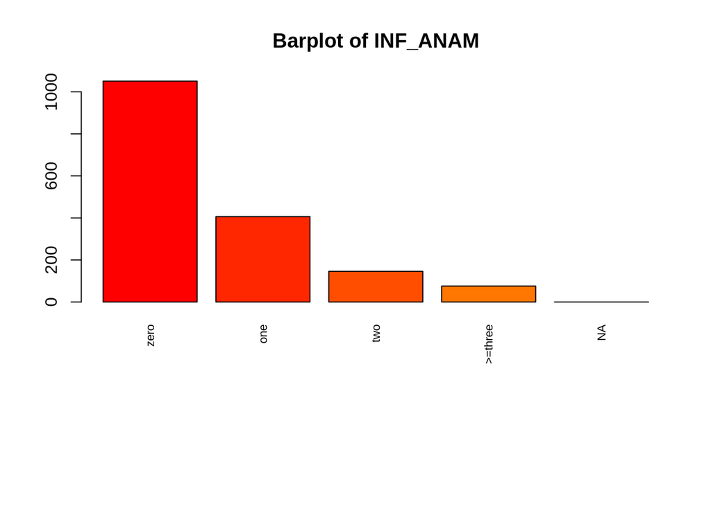

```
## [1] "Number of modalities:  5"
## [1] "Frequency table"
##
##    zero     one     two >=three      NA
##    1051     406     146      76       0
## [1] "Relative frequency table (proportions)"
##
##       zero        one        two    >=three         NA
## 0.62596784 0.24181060 0.08695652 0.04526504 0.00000000
## [1] "Frequency table sorted"
##
##    zero     one     two >=three      NA
##    1051     406     146      76       0
## [1] "Relative frequency table (proportions) sorted"
##
##       zero        one        two    >=three         NA
## 0.62596784 0.24181060 0.08695652 0.04526504 0.00000000
## [1] "variable  3 : STENOK_AN"
```

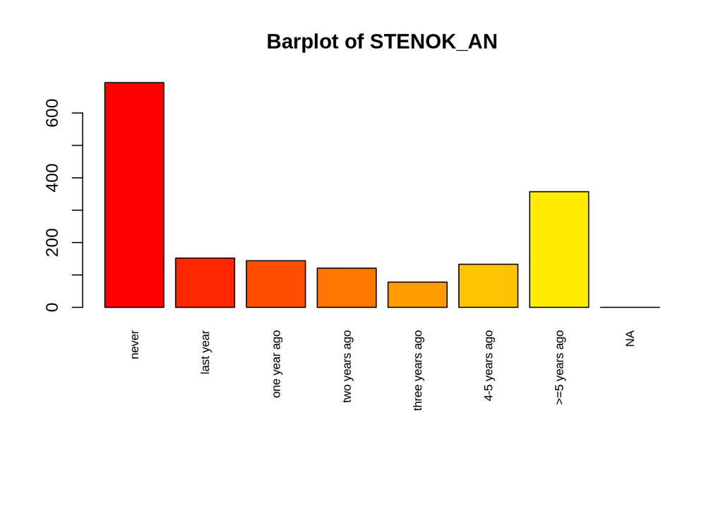

```
## [1] "Number of modalities:  8"
## [1] "Frequency table"
##
##           never       last year    one year ago   two years ago three years ago
##             694             152             144             121              78
##   4-5 years ago   >=5 years ago              NA
##             133             357               0
## [1] "Relative frequency table (proportions)"
##
##           never       last year    one year ago   two years ago three years ago
##      0.41334127      0.09053008      0.08576534      0.07206671      0.04645622
##   4-5 years ago   >=5 years ago              NA
##      0.07921382      0.21262656      0.00000000
## [1] "Frequency table sorted"
##
##           never   >=5 years ago       last year    one year ago   4-5 years ago
##             694             357             152             144             133
##   two years ago three years ago              NA
##             121              78               0
## [1] "Relative frequency table (proportions) sorted"
##
##           never   >=5 years ago       last year    one year ago   4-5 years ago
##      0.41334127      0.21262656      0.09053008      0.08576534      0.07921382
##   two years ago three years ago              NA
##      0.07206671      0.04645622      0.00000000
## [1] "variable  4 : GB"
```

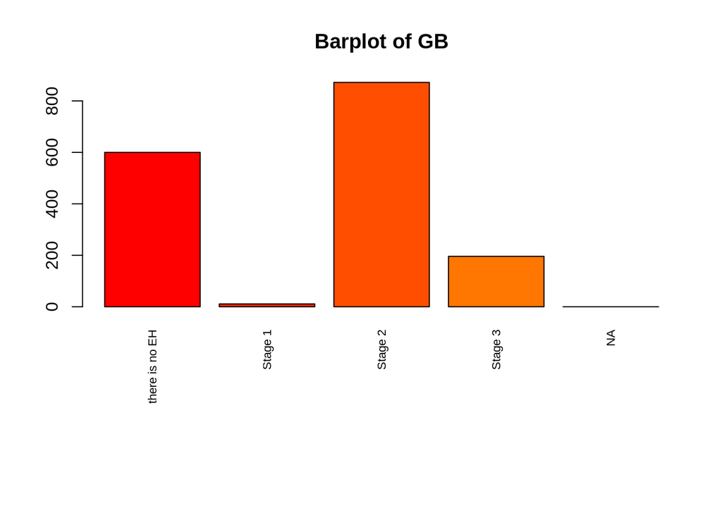

```
## [1] "Number of modalities:  5"
## [1] "Frequency table"
##
## there is no EH        Stage 1        Stage 2        Stage 3             NA
##            600             11            872            196              0
## [1] "Relative frequency table (proportions)"
##
## there is no EH        Stage 1        Stage 2        Stage 3             NA
##    0.357355569    0.006551519    0.519356760    0.116736152    0.000000000
## [1] "Frequency table sorted"
##
##        Stage 2 there is no EH        Stage 3        Stage 1             NA
##            872            600            196             11              0
## [1] "Relative frequency table (proportions) sorted"
##
##        Stage 2 there is no EH        Stage 3        Stage 1             NA
##    0.519356760    0.357355569    0.116736152    0.006551519    0.000000000
## [1] "variable  5 : SIM_GIPERT"
```

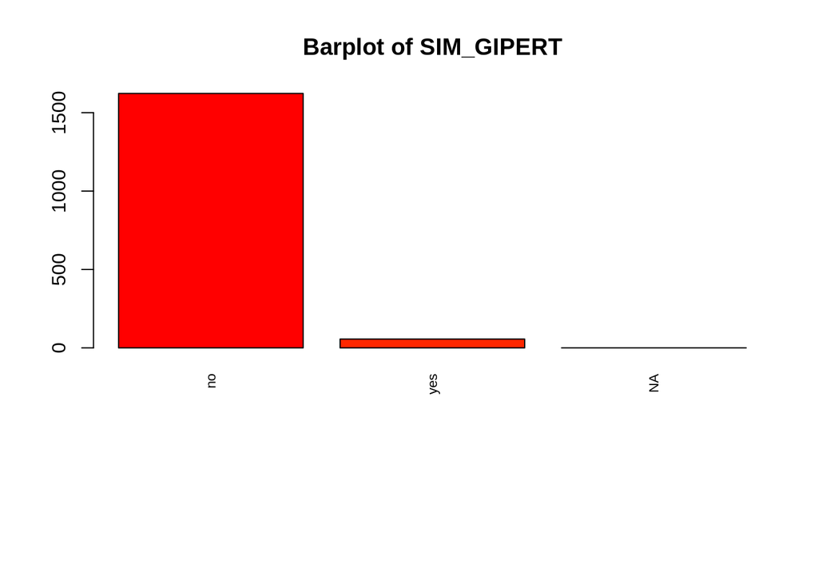

```
## [1] "Number of modalities:  3"
## [1] "Frequency table"
##
##   no  yes   NA
## 1623   56    0
## [1] "Relative frequency table (proportions)"
##
##         no        yes         NA
## 0.96664681 0.03335319 0.00000000
## [1] "Frequency table sorted"
##
##   no  yes   NA
## 1623   56    0
## [1] "Relative frequency table (proportions) sorted"
##
##         no        yes         NA
## 0.96664681 0.03335319 0.00000000
## [1] "variable  6 : endocr_01"
```

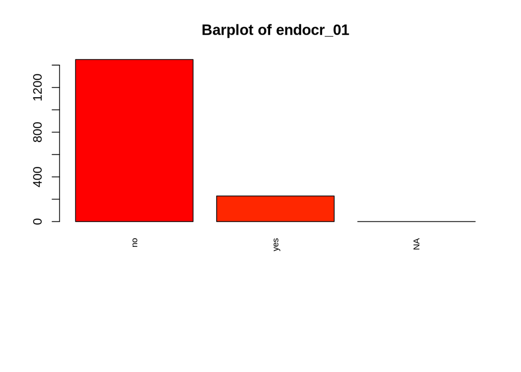

```
## [1] "Number of modalities:  3"
## [1] "Frequency table"
##
##   no  yes   NA
## 1450  229    0
## [1] "Relative frequency table (proportions)"
##
##        no       yes        NA
## 0.8636093 0.1363907 0.0000000
## [1] "Frequency table sorted"
##
##   no  yes   NA
## 1450  229    0
## [1] "Relative frequency table (proportions) sorted"
##
##        no       yes        NA
## 0.8636093 0.1363907 0.0000000
## [1] "variable  7 : ZSN_A"
```

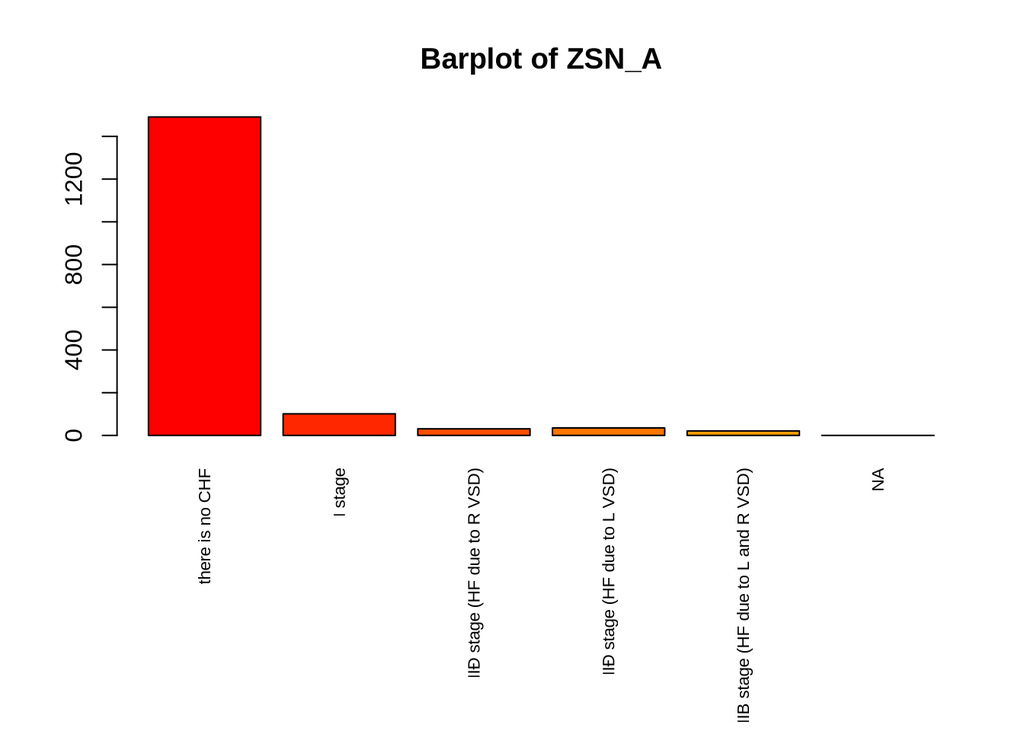

```
## [1] "Number of modalities:  6"
## [1] "Frequency table"
##
##                   there is no CHF                           I stage
##                              1491                               101
##       IIÐ stage (HF due to R VSD)       IIÐ stage (HF due to L VSD)
##                                31                                35
## IIB stage (HF due to L and R VSD)                                NA
##                                21                                 0
## [1] "Relative frequency table (proportions)"
##
##                   there is no CHF                           I stage
##                        0.88802859                        0.06015485
##       IIÐ stage (HF due to R VSD)       IIÐ stage (HF due to L VSD)
##                        0.01846337                        0.02084574
## IIB stage (HF due to L and R VSD)                                NA
##                        0.01250744                        0.00000000
## [1] "Frequency table sorted"
##
##                   there is no CHF                           I stage
##                              1491                               101
##       IIÐ stage (HF due to L VSD)       IIÐ stage (HF due to R VSD)
##                                35                                31
## IIB stage (HF due to L and R VSD)                                NA
##                                21                                 0
## [1] "Relative frequency table (proportions) sorted"
##
##                   there is no CHF                           I stage
##                        0.88802859                        0.06015485
##       IIÐ stage (HF due to L VSD)       IIÐ stage (HF due to R VSD)
##                        0.02084574                        0.01846337
## IIB stage (HF due to L and R VSD)                                NA
##                        0.01250744                        0.00000000
## [1] "variable  8 : AGE"
```

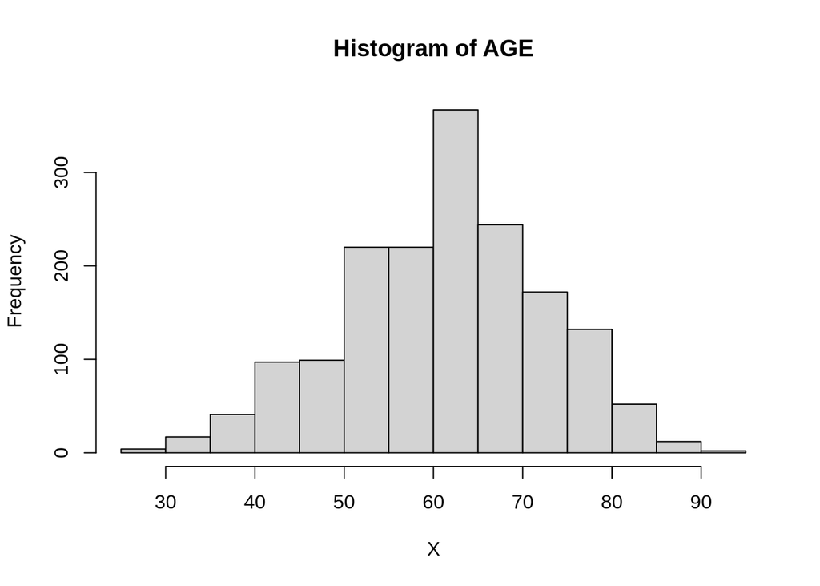

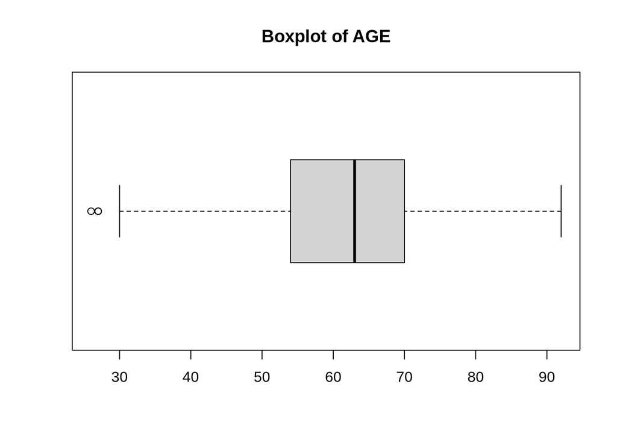

```
## [1] "Extended Summary Statistics"
##    Min. 1st Qu.  Median    Mean 3rd Qu.    Max.
##   26.00   54.00   63.00   61.84   70.00   92.00
## [1] "sd:  11.2525268063899"
## [1] "vc:  0.181971340999467"
## [1] "Q-Q plot "
```

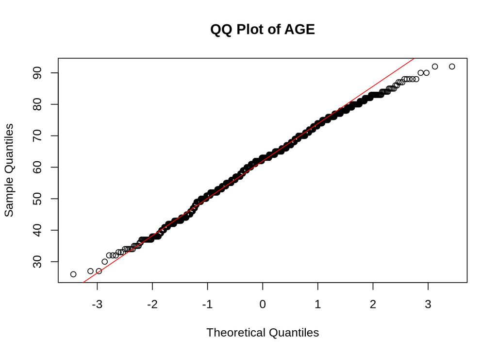

```
##
##  Shapiro-Wilk normality test
##
## data:  X
## W = 0.99347, p-value = 9.109e-07
##
## [1] "variable  9 : S_AD_ORIT"
```

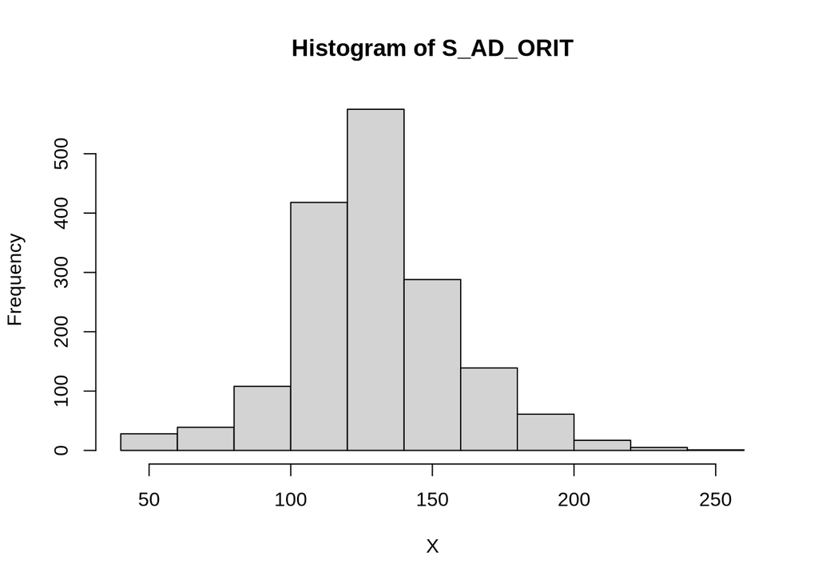

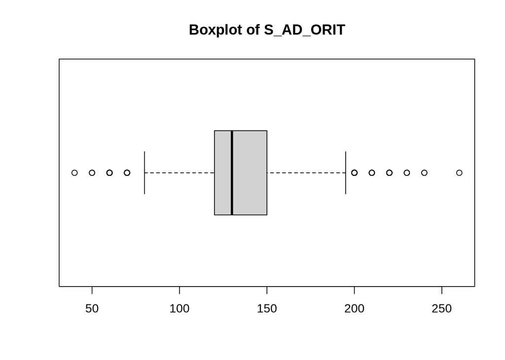

```
## [1] "Extended Summary Statistics"
##    Min. 1st Qu.  Median    Mean 3rd Qu.    Max.
##    40.0   120.0   130.0   135.5   150.0   260.0
## [1] "sd:  28.8630352776447"
## [1] "vc:  0.213029589780273"
## [1] "Q-Q plot "
```

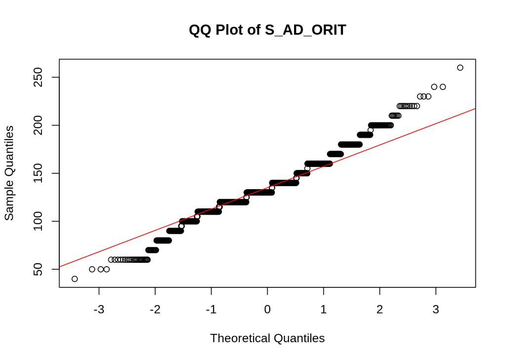

```
##
##  Shapiro-Wilk normality test
##
## data:  X
## W = 0.97312, p-value < 2.2e-16
##
## [1] "variable  10 : D_AD_ORIT"
```

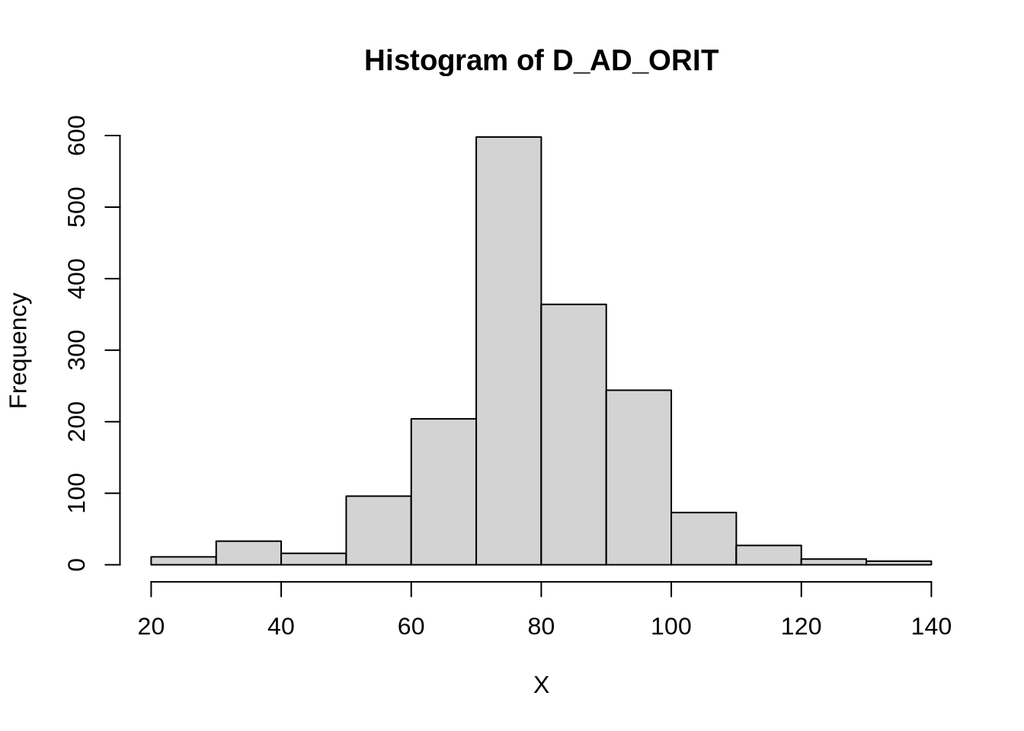

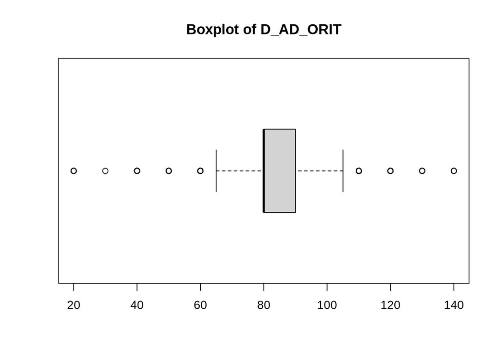

```
## [1] "Extended Summary Statistics"
##    Min. 1st Qu.  Median    Mean 3rd Qu.    Max.
##   20.00   80.00   80.00   83.55   90.00  140.00
## [1] "sd:  15.8524762820447"
## [1] "vc:  0.189730246837175"
## [1] "Q-Q plot "
```

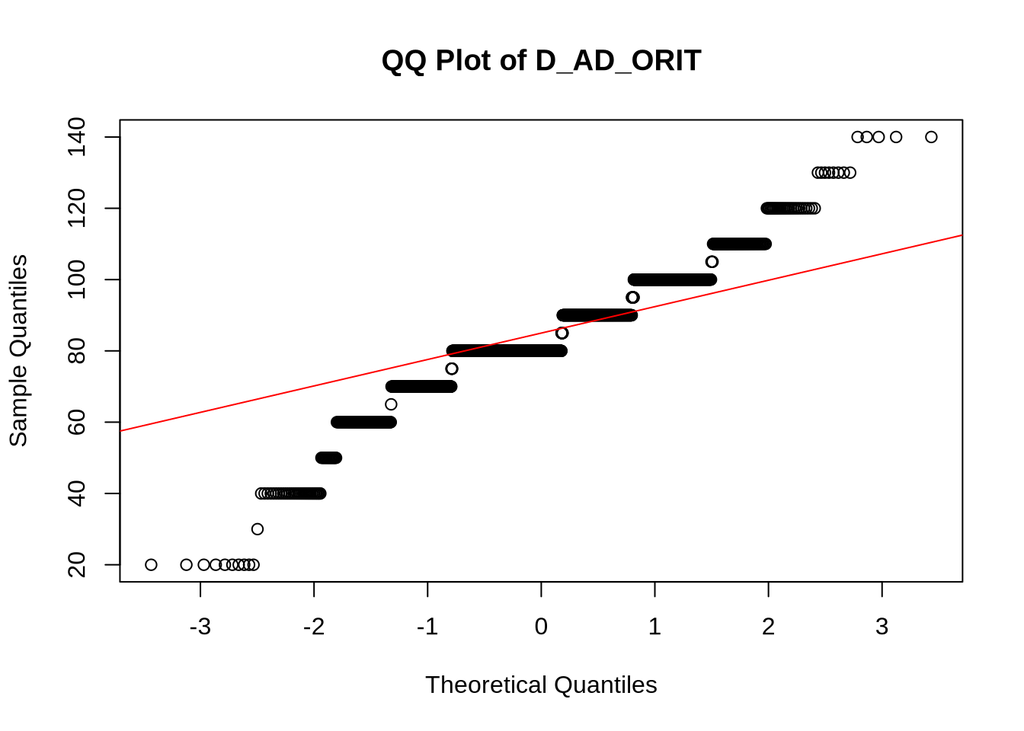

```
##
##  Shapiro-Wilk normality test
##
## data:  X
## W = 0.93218, p-value < 2.2e-16
##
## [1] "variable  11 : K_BLOOD"
```

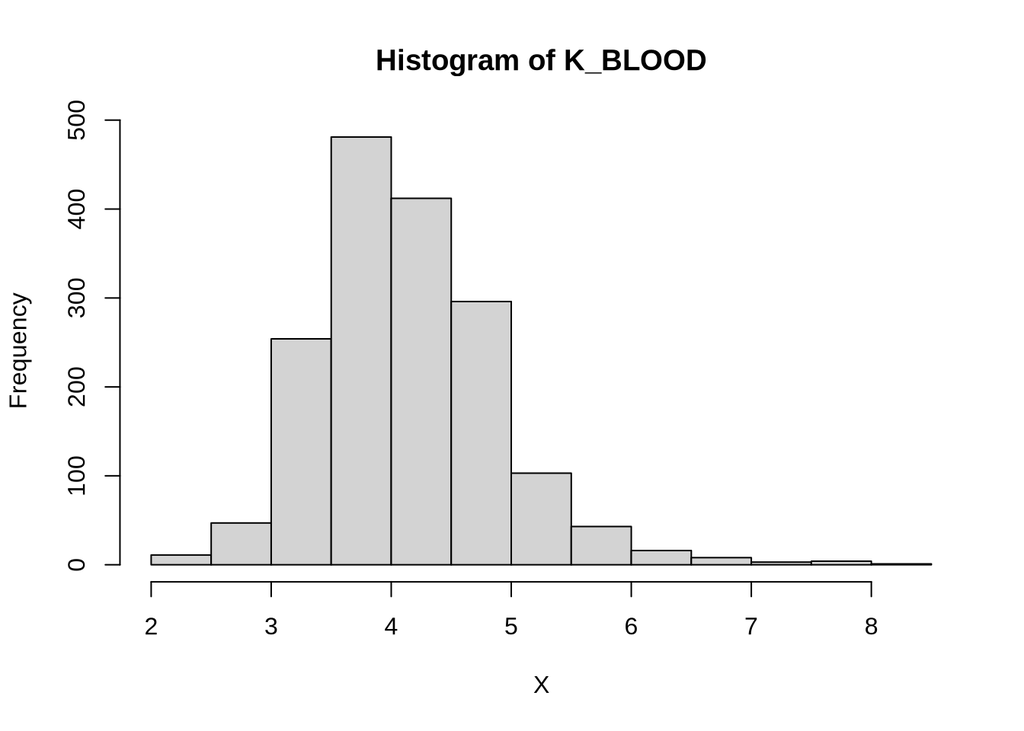

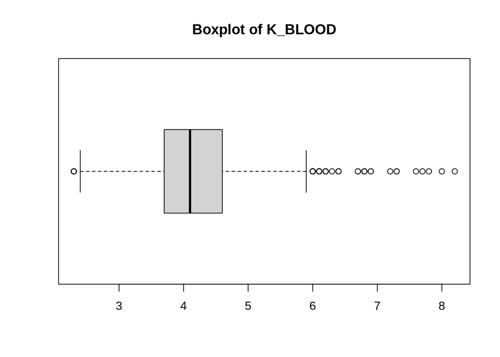

```
## [1] "Extended Summary Statistics"
##    Min. 1st Qu.  Median    Mean 3rd Qu.    Max.
##   2.300   3.700   4.100   4.193   4.600   8.200
## [1] "sd:  0.749412410681622"
## [1] "vc:  0.17871283218067"
## [1] "Q-Q plot "
```

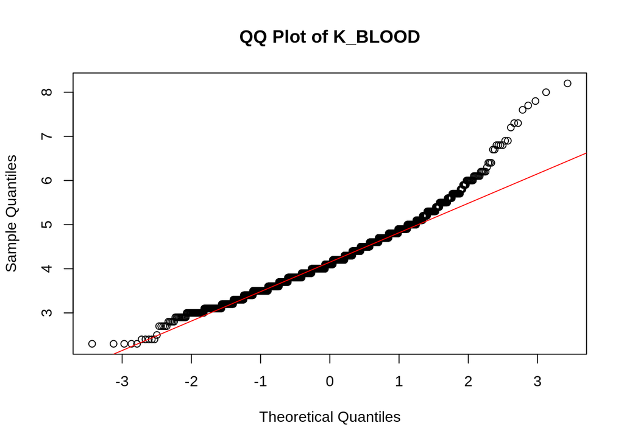

```
##
##  Shapiro-Wilk normality test
##
## data:  X
## W = 0.96139, p-value < 2.2e-16
##
## [1] "variable  12 : NA_BLOOD"
```

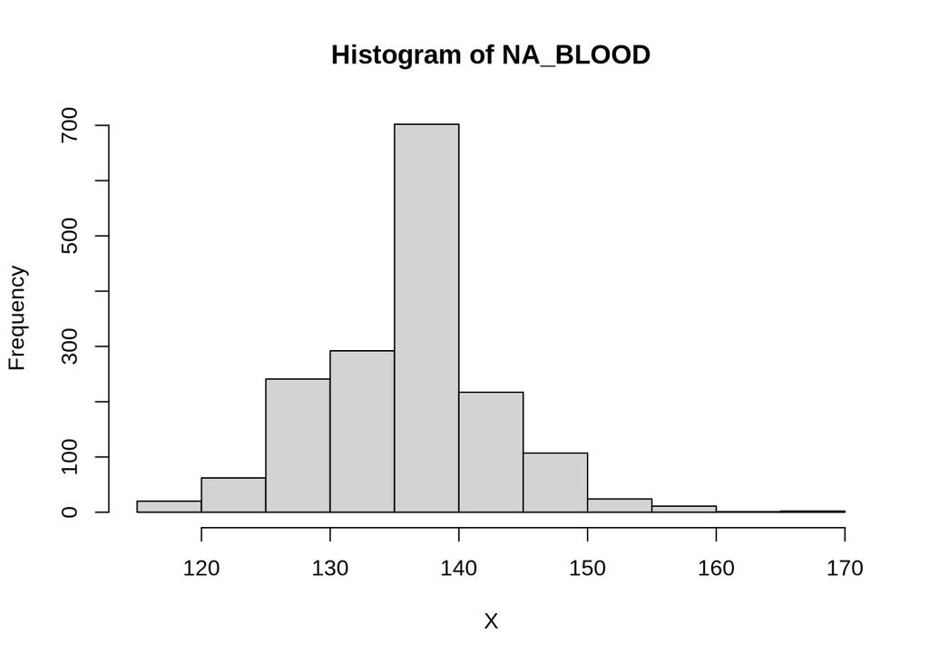

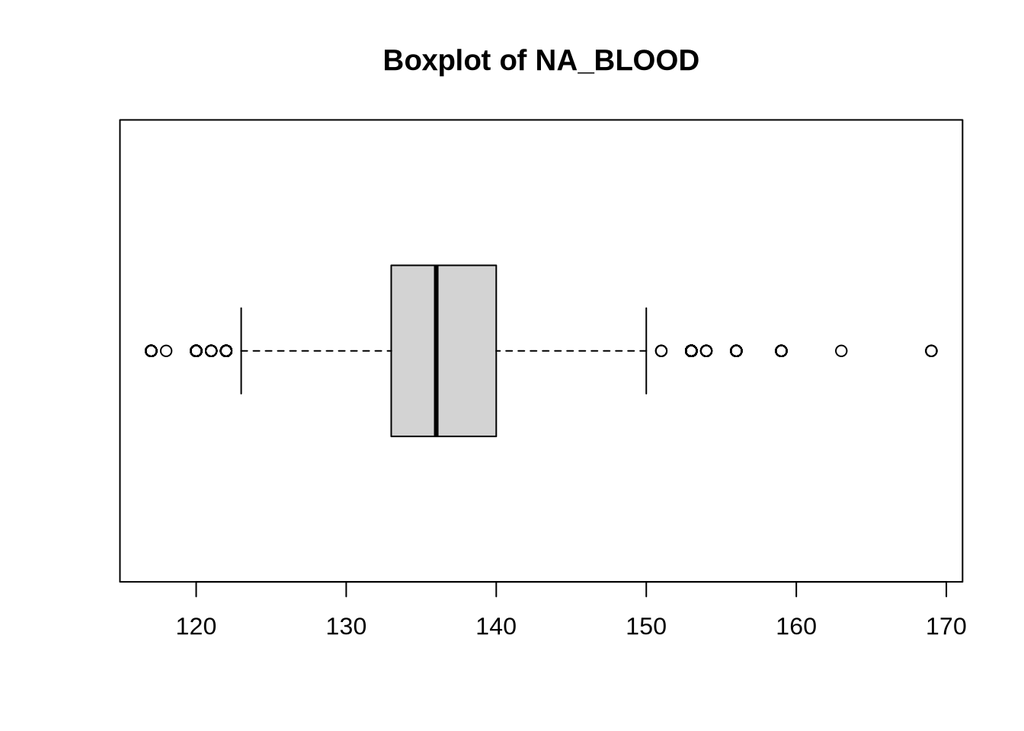

```
## [1] "Extended Summary Statistics"
##    Min. 1st Qu.  Median    Mean 3rd Qu.    Max.
##   117.0   133.0   136.0   136.7   140.0   169.0
## [1] "sd:  6.54936748984086"
## [1] "vc:  0.0479243593042706"
## [1] "Q-Q plot "
```

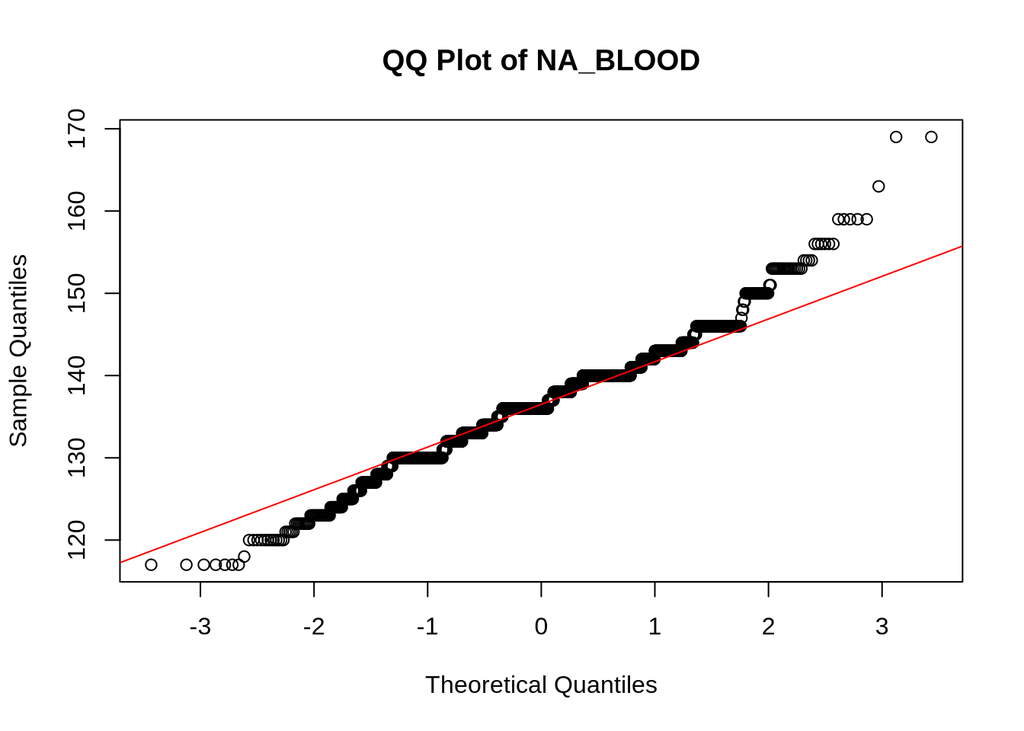

```
##
##  Shapiro-Wilk normality test
##
## data:  X
## W = 0.97837, p-value = 3.153e-15
##
## [1] "variable  13 : L_BLOOD"
```

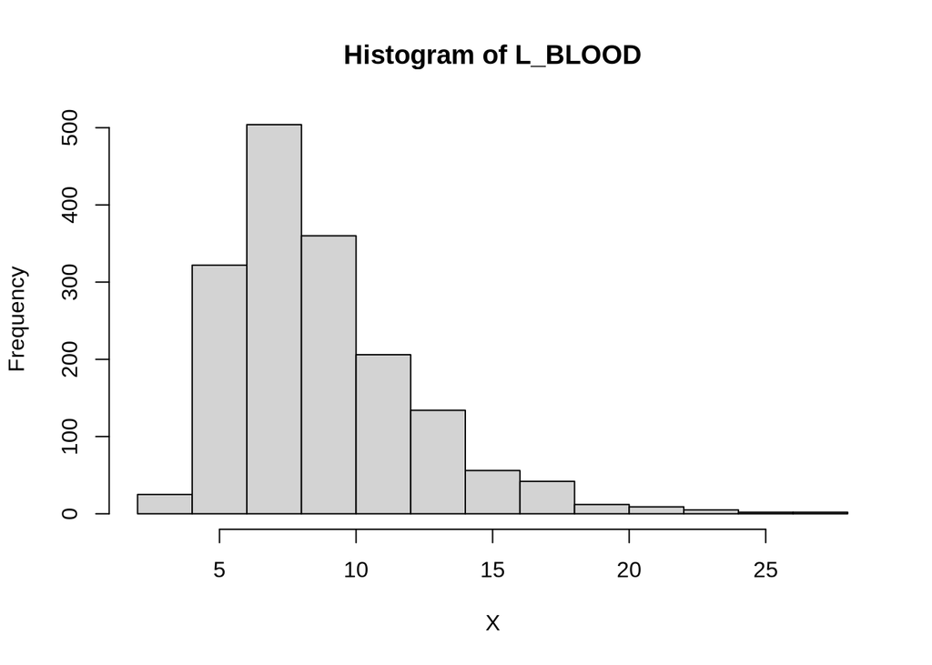

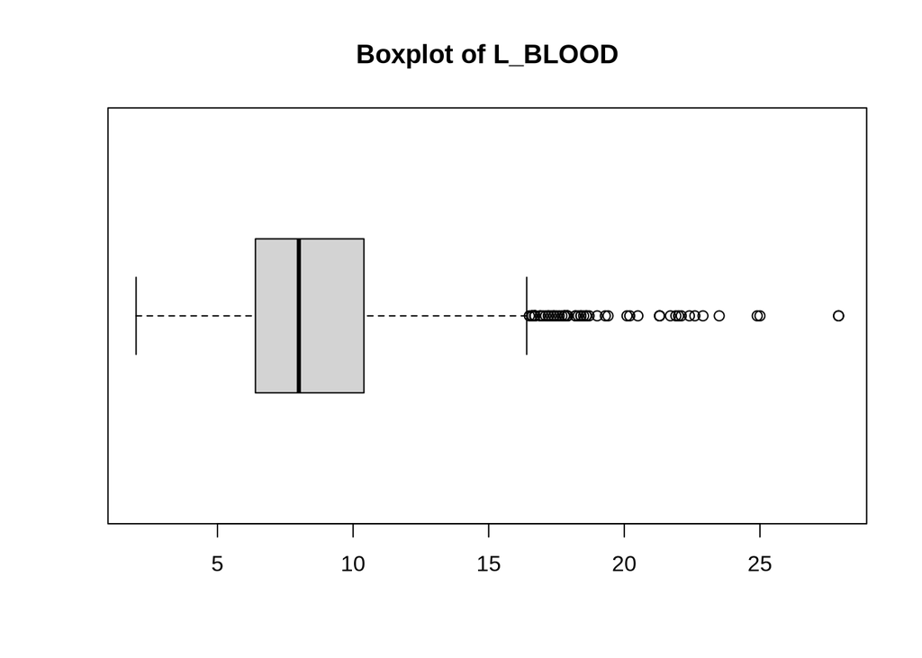

```
## [1] "Extended Summary Statistics"
##    Min. 1st Qu.  Median    Mean 3rd Qu.    Max.
##   2.000   6.400   8.000   8.794  10.400  27.900
## [1] "sd:  3.4087770886945"
## [1] "vc:  0.387607891749651"
## [1] "Q-Q plot "
```

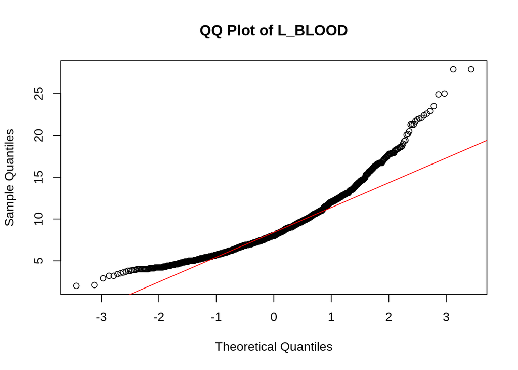

```
##
##  Shapiro-Wilk normality test
##
## data:  X
## W = 0.91096, p-value < 2.2e-16
##
## [1] "variable  14 : ROE"
```

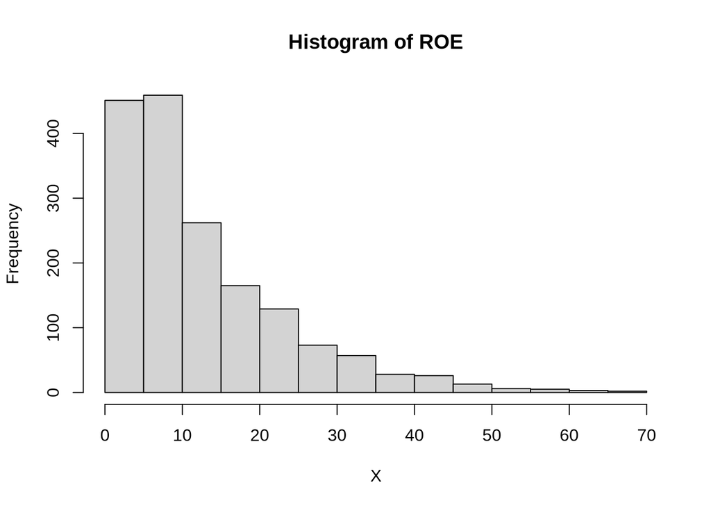

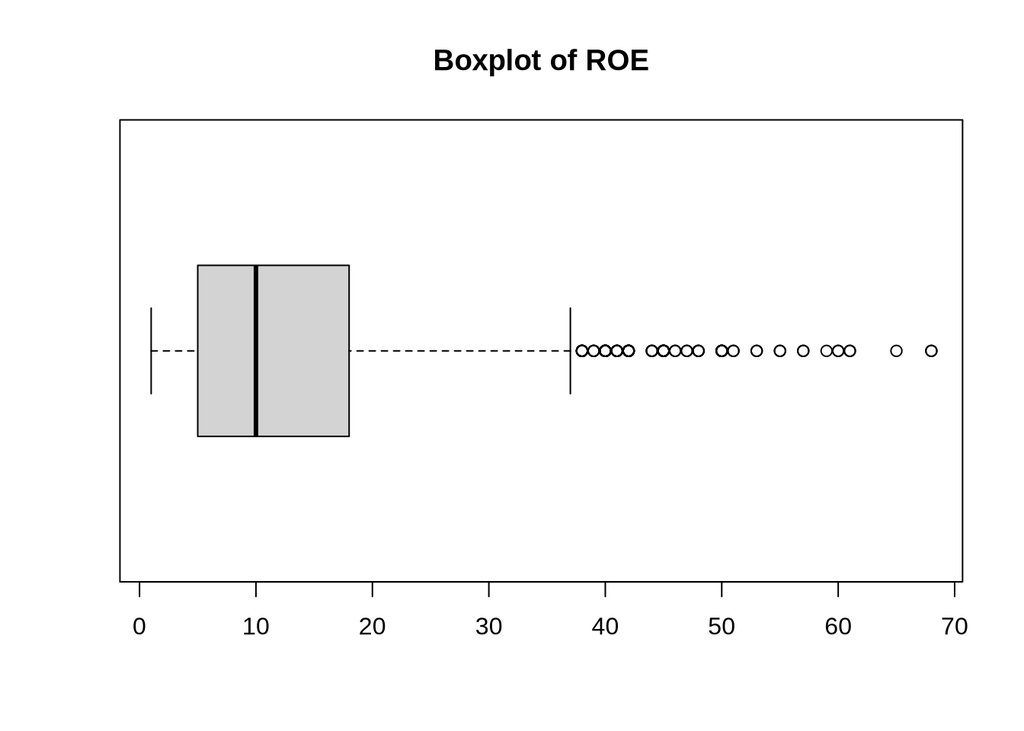

```
## [1] "Extended Summary Statistics"
##    Min. 1st Qu.  Median    Mean 3rd Qu.    Max.
##    1.00    5.00   10.00   13.42   18.00   68.00
## [1] "sd:  10.9737446828071"
## [1] "vc:  0.817504539996148"
## [1] "Q-Q plot "
```

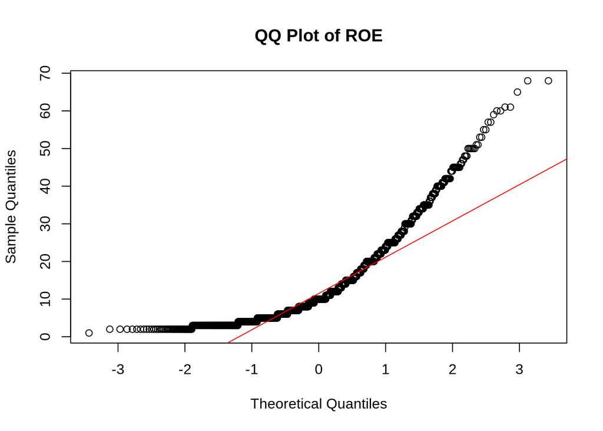

```
##
##  Shapiro-Wilk normality test
##
## data:  X
## W = 0.84, p-value < 2.2e-16
##
## [1] "variable  15 : LET_IS"
```

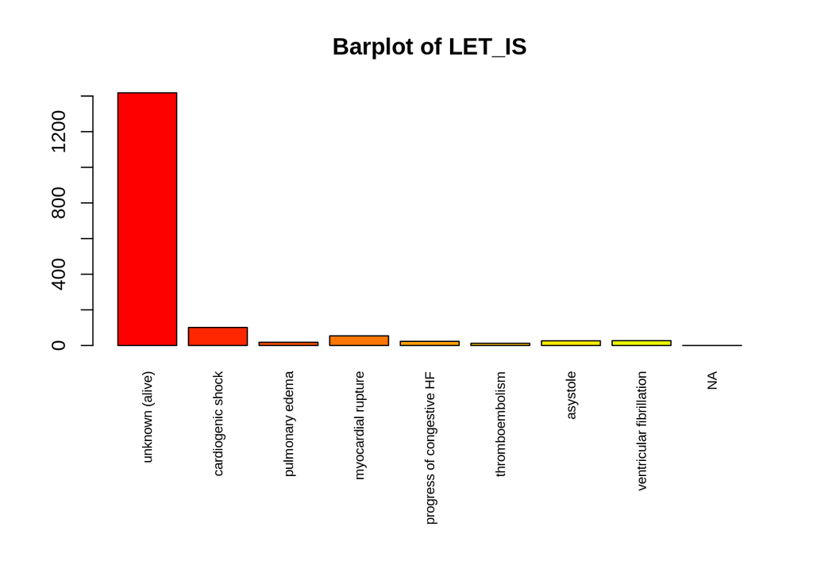

```
## [1] "Number of modalities:  9"
## [1] "Frequency table"
##
##           unknown (alive)         cardiogenic shock           pulmonary edema
##                      1418                       101                        18
##        myocardial rupture progress of congestive HF           thromboembolism
##                        54                        23                        12
##                  asystole  ventricular fibrillation                        NA
##                        26                        27                         0
## [1] "Relative frequency table (proportions)"
##
##           unknown (alive)         cardiogenic shock           pulmonary edema
##               0.844550328               0.060154854               0.010720667
##        myocardial rupture progress of congestive HF           thromboembolism
##               0.032162001               0.013698630               0.007147111
##                  asystole  ventricular fibrillation                        NA
##               0.015485408               0.016081001               0.000000000
## [1] "Frequency table sorted"
##
##           unknown (alive)         cardiogenic shock        myocardial rupture
##                      1418                       101                        54
##  ventricular fibrillation                  asystole progress of congestive HF
##                        27                        26                        23
##           pulmonary edema           thromboembolism                        NA
##                        18                        12                         0
## [1] "Relative frequency table (proportions) sorted"
##
##           unknown (alive)         cardiogenic shock        myocardial rupture
##               0.844550328               0.060154854               0.032162001
##  ventricular fibrillation                  asystole progress of congestive HF
##               0.016081001               0.015485408               0.013698630
##           pulmonary edema           thromboembolism                        NA
##               0.010720667               0.007147111               0.000000000
## [1] "variable  16 : COM_SUM"
```

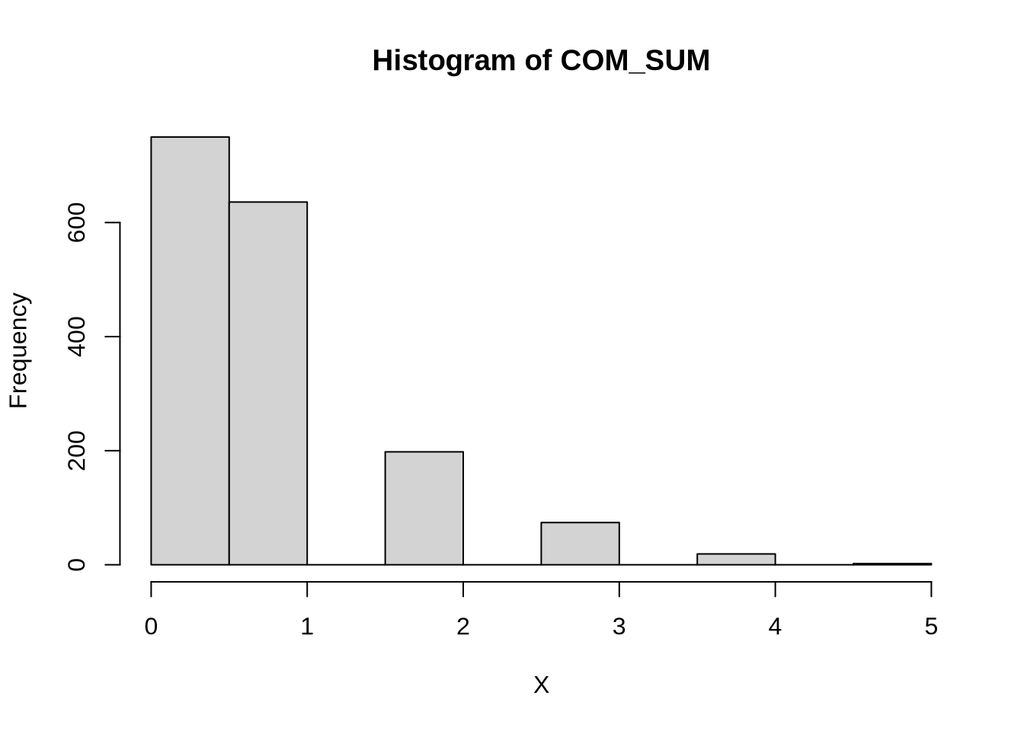

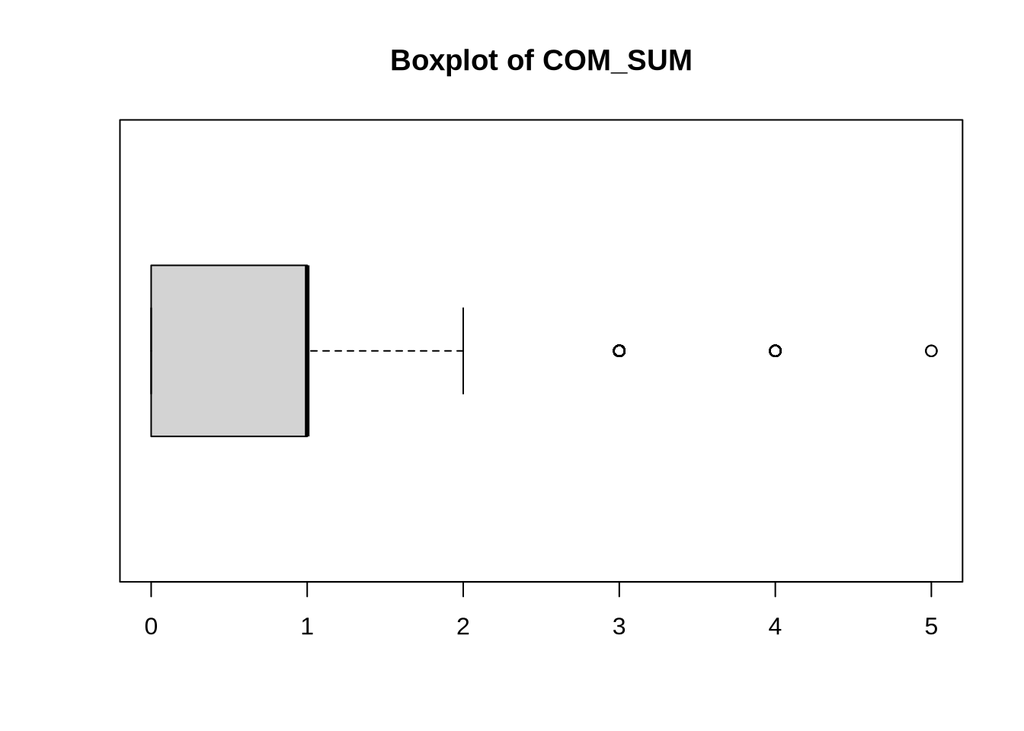

```
## [1] "Extended Summary Statistics"
##    Min. 1st Qu.  Median    Mean 3rd Qu.    Max.
##  0.0000  0.0000  1.0000  0.7981  1.0000  5.0000
## [1] "sd:  0.906391653228059"
## [1] "vc:  1.13569521326113"
## [1] "Q-Q plot "
```

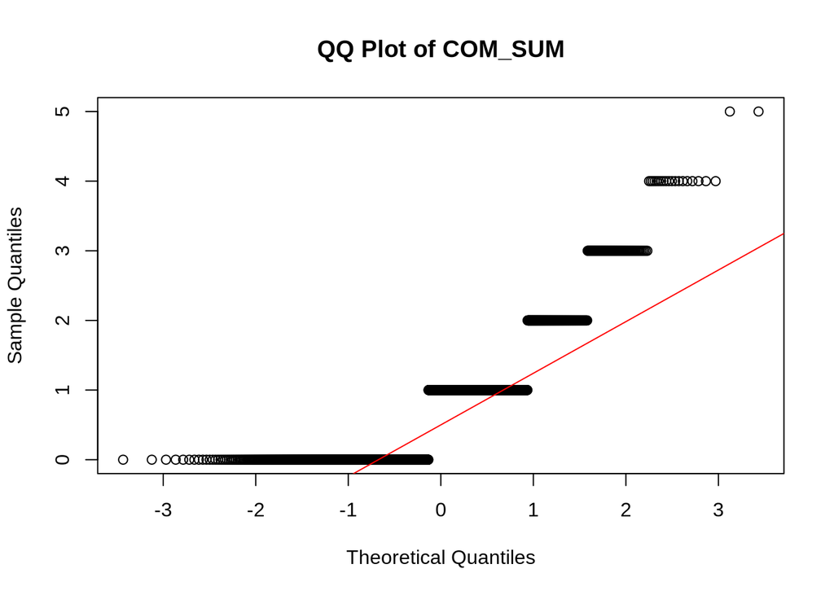

```
##
##  Shapiro-Wilk normality test
##
## data:  X
## W = 0.78494, p-value < 2.2e-16
```